[figure not shown]

# PAO25_25_09_Python_Visualization

## 0.1 01MIAR - Representación Gráfica

[figure not shown]

*Jesús Viera* https://github.com/Vierita23/machinelearning

## Representación gráfica

• matplotlib básico (plot, legend, decoradores y anotaciones, grabar) • dibujo con pandas (tipos de gráficos) • intro a seaborn https://seaborn.pydata.org/tutorial.html

### Referencias

• https://plotdb.com/ • https://plotnine.org/ • https://d3js.org/ • https://plot.ly/python/ • https://bokeh.org/ • https://shiny.rstudio.com/gallery/ • https://www.tableau.com/es-es

# 1 matplotlib

• Librería estándar de representación gráfica • Low level: fácil de usar, difícil de dominar • Control • Gráficos y diagramas

### 1.0.1 Elementos de visualización

• **Gráfico.** Tipo de representación dentro de una subfigura o figura. Existen gran cantidad de tipos de gráficos: barras, líneas, tarta… • **Subfigura.** Representación dentro de una figura. • **Figura.** Marco donde se representan de manera conjunta una visualización. Se caracterizan por tener un título general y suele tener una descripción así como una fuente o referencia

```python
# Celda de arranque: instala dependencias si faltan e importa las librerías de gráficos
import sys
# subprocess permite lanzar procesos externos (aquí pip) desde Python
import subprocess

# Ejecuta pip install en el mismo intérprete que ejecuta este notebook
subprocess.run(
    [sys.executable, "-m", "pip", "install", "matplotlib", "numpy", "pandas", "seaborn", "-q"],
    # check=False evita excepción si pip ya tiene los paquetes instalados
    check=False,
)

# Alias plt es la API principal de Matplotlib para crear gráficos
import matplotlib.pyplot as plt
# NumPy provee arrays numéricos eficientes para los datos de los gráficos
import numpy as np
# Pandas aporta DataFrames con métodos .plot() de alto nivel
import pandas as pd
# display renderiza objetos (arrays, DataFrames) con formato enriquecido en Jupyter
from IPython.display import display

# Confirma qué ejecutable de Python está usando el kernel
print("Python:", sys.executable)
# Muestra la versión instalada de Matplotlib para verificar la instalación
print("matplotlib:", plt.matplotlib.__version__)
```

[output not shown]

```python
# Reimporta las librerías por si se ejecuta esta celda sin la celda de instalación
import matplotlib.pyplot as plt
# NumPy para generar y manipular los datos numéricos de los ejemplos
import numpy as np
# Pandas para ejemplos de gráficos desde DataFrames
import pandas as pd
# display para mostrar tablas y arrays en el notebook
from IPython.display import display
```

• `plot(data)` para crear un gráfico con `data` • `show()` para mostrarlo

```python
# Lista los backends de Matplotlib disponibles en este entorno (inline, notebook, etc.)
%matplotlib --list
```

```
Available matplotlib backends: ['agg', 'auto', 'cairo', 'gtk3', 'gtk3agg', 'gtk3cairo', 'gtk4', 'gtk4agg', 'gtk4cairo', 'inline', 'ipympl', 'macosx', 'nbagg', 'notebook', 'osx', 'pdf', 'pgf', 'ps', 'qt', 'qt5', 'qt5agg', 'qt5cairo', 'qt6', 'qtagg', 'qtcairo', 'svg', 'template', 'tk', 'tkagg', 'tkcai…
```

```python
# Activa el backend 'inline' para incrustar gráficos estáticos en la salida del notebook
%matplotlib inline
```

```
array([[29, 88, 85],
       [52,  8, 82],
       [54, 51, 36]], dtype=int32)
```

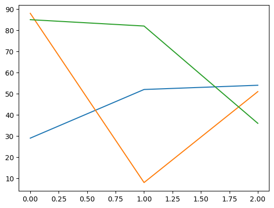

```python
# Genera una matriz 3x3 de enteros aleatorios entre 0 y 99
data = np.random.randint(100, size=(3, 3))
# Muestra la matriz en formato tabular dentro de la celda
display(data)
# Trazar cada fila de la matriz como una serie (línea) en el mismo gráfico
plt.plot(data)  # creación del gráfico
# Renderiza en pantalla todas las figuras pendientes de mostrar
plt.show()  # comando que muestra los gráficos creados hasta el momento
```

```python
# Cambia al backend interactivo que permite zoom y pan en el navegador
%matplotlib notebook
plt.ioff()  # evitar que se sobreescriban los gráficos
# Vuelve a inline para los ejemplos siguientes del notebook
%matplotlib inline
```

```
[75 76 77 78 79 80 81 82 83 84 85 86 87 88 89 90 91 92 93 94 95 96 97 98
 99] [58 54 25  2 27  2 78 39 61 53 42 55 38 63 72 60 46 11 22  8 73 38 47 42
 67]
```

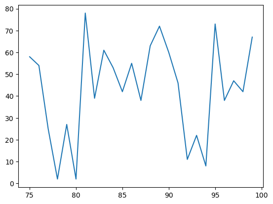

```python
# Eje X: 25 enteros consecutivos del 75 al 99 inclusive
x_data = np.arange(75, 100)  # dimensiones!
# Eje Y: 25 valores aleatorios entre 0 y 79 (misma longitud que x_data)
y_data = np.random.randint(80, size=(25))
# Depuración: verifica que ambos arrays tienen el mismo tamaño antes de graficar
print(x_data, y_data)
# Solo grafica si hay la misma cantidad de puntos en X e Y (requisito de plt.plot)
if x_data.size == y_data.size:
    # Dibuja la relación entre cada par (x_data[i], y_data[i])
    plt.plot(x_data, y_data)
    # Muestra el gráfico de líneas generado
    plt.show()
# Si las dimensiones difieren, informa el error en lugar de graficar
else:
    # Mensaje que indica el desajuste de tamaños entre ejes
    print(f"{x_data.size} no tienen las mismas dimensiones {y_data.size}")
```

## 1.1 figure, axes

• **Figure:** objeto en el que residen todos los gráficos (uno o múltiples) • **Axes:** cada uno de los subplots (o gráficos) dentro de Figure

```
<class 'numpy.ndarray'>
(3, 2)
```

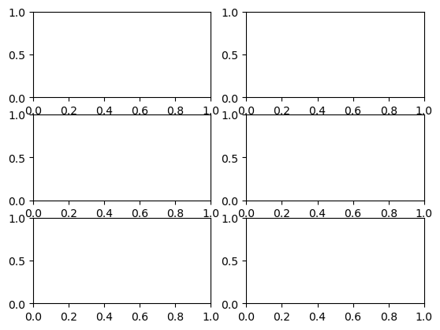

```python
# Crea una figura con rejilla de 3 filas × 2 columnas de subplots vacíos
fig, axes = plt.subplots(3, 2)  # crea una ndarray de 3x2 axes (o subplots)
# axes es un ndarray de objetos Axes, no una lista simple
print(type(axes))
# Confirma la forma (3, 2) del array de ejes
print(axes.shape)
```

```python
# Serie X para el subplot izquierdo: enteros de 0 a 9
x_data1 = np.arange(0, 10)
# Serie X para el subplot derecho: enteros de -10 a -1
x_data2 = np.arange(-10, 0)
# 10 valores aleatorios (0-99) que acompañarán a x_data1
y_data1 = np.random.randint(100, size=(10))
# 10 valores aleatorios (0-999) para el segundo subplot
y_data2 = np.random.randint(1000, size=(10))
```

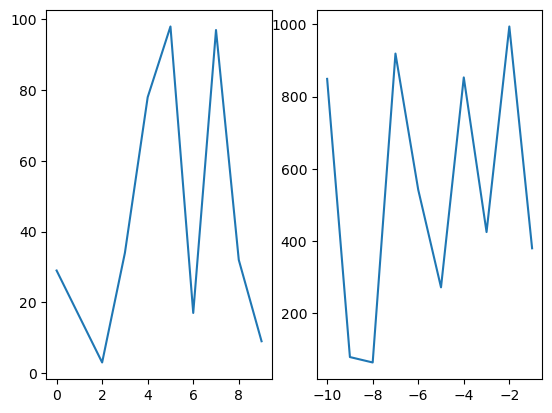

```python
# Figura con dos subplots en una fila para comparar dos series
fig, axes = plt.subplots(1, 2)
# Gráfico de líneas en el eje izquierdo (índice 0)
axes[0].plot(x_data1, y_data1)
# Gráfico de líneas en el eje derecho (índice 1)
axes[1].plot(x_data2, y_data2)
# plt.show() actualiza y muestra la figura completa con ambos ejes
plt.show()  # Recomendable usar plt y no fig.show()
```

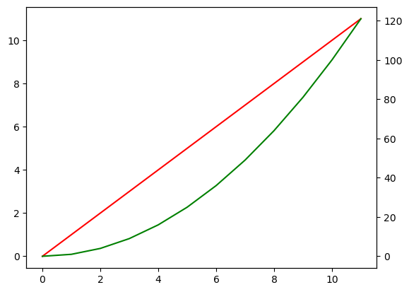

```python
# Un solo subplot donde superpondremos dos series con escalas Y distintas
fig, ax = plt.subplots(1, 1)
# Valores del eje X: meses o índices del 0 al 11
x = np.arange(12)
# Primera serie en rojo ('r') sobre el eje Y principal de ax
ax.plot(x, "r")
# twinx() crea un segundo eje Y que comparte el mismo eje X
ax2 = ax.twinx()
# Segunda serie (x²) en verde sobre el eje Y secundario ax2
ax2.plot(x ** 2, "g")
# Renderiza ambas series en la misma figura
plt.show()
```

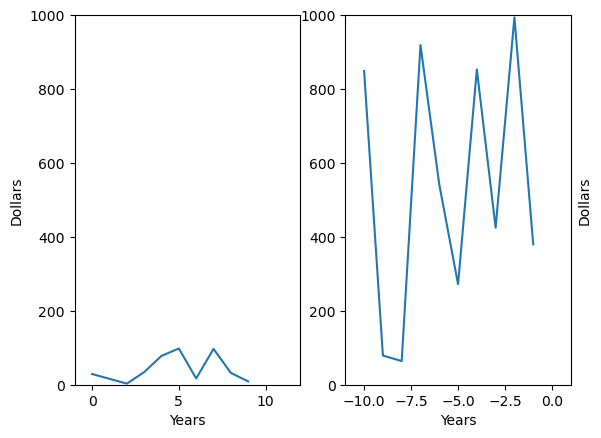

```python
# Repite la figura de dos subplots para personalizar límites y etiquetas
fig, axes = plt.subplots(1, 2)
# Trazado de la primera serie en el subplot izquierdo
axes[0].plot(x_data1, y_data1)
# Trazado de la segunda serie en el subplot derecho
axes[1].plot(x_data2, y_data2)
# Fija el rango vertical del eje Y izquierdo entre 0 y 1000
axes[0].set_ylim([0, 1000])
# Fija el rango horizontal del eje X izquierdo entre -1 y 12
axes[0].set_xlim([-1, 12])
# Etiqueta del eje X del subplot izquierdo
axes[0].set_xlabel("Years")
# Etiqueta del eje Y del subplot izquierdo
axes[0].set_ylabel("Dollars")
# Mismos límites verticales para el subplot derecho
axes[1].set_ylim([0, 1000])
# Rango horizontal adaptado a los valores negativos de x_data2
axes[1].set_xlim([-11, 1])
# Etiqueta del eje X del subplot derecho
axes[1].set_xlabel("Years")
# Etiqueta Y derecha desplazada con labelpad para evitar solapamiento
axes[1].set_ylabel("Dollars", loc="center", labelpad=-210)
# Muestra la figura con todas las personalizaciones aplicadas
plt.show()
```

### 1.1.1 Más métodos

• Documentación general de la API

## 2 .plot()

Múltiples parámetros

`plt.plot(x, y, style, label, linewidth=1, alpha=1)`

• `style`: cadena de texto con formato (color, tipo…) [color][marker][line] • `label`: referencia para leyenda • `linewidth`: brocha • `alpha`: transparencia

Otros: https://matplotlib.org/stable/api/_as_gen/matplotlib.pyplot.plot.html

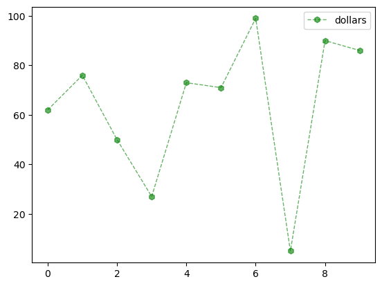

```python
# 10 valores aleatorios que serán las alturas de la línea
y_data = np.random.randint(100, size=(10))
# Índices 0..9 como coordenadas X
x_data = np.arange(10)
# Un único eje para el gráfico con estilo personalizado
fig, axis = plt.subplots(1, 1)
# Línea verde con marcadores hexagonales, estilo discontinuo, semitransparente
axis.plot(x_data, y_data, 'gh--', label='dollars', linewidth=1, alpha=0.6)  # creación del gráfico
# Muestra la leyenda con la etiqueta 'dollars' en la mejor posición automática
axis.legend(loc='best')  # representar la leyenda
# Renderiza el gráfico final
plt.show()
```

| Color | Descripción |
| --- | --- |
| b | blue |
| g | green |
| r | red |
| c | cyan |
| m | magenta |
| y | yellow |
| k | black |
| w | white |

| Marcador | Descripción |
| --- | --- |
| . | point marker |
| , | pixel marker |
| o | circle marker |
| v | triangle_down marker |
| ^ | triangle_up marker |
| < | triangle_left marker |
| > | triangle_right marker |
| 1 | tri_down marker |
| 2 | tri_up marker |
| 3 | tri_left marker |
| 4 | tri_right marker |
| s | square marker |
| p | pentagon marker |
| * | star marker |
| h | hexagon1 marker |
| H | hexagon2 marker |
| + | plus marker |
| x | x marker |
| D | diamond marker |
| d | thin_diamond marker |
| _ | hline marker |

| Línea | Descripción |
| --- | --- |
| - | solid line style |
| -- | dashed line style |
| -. | dash-dot line style |
| : | dotted line style |

### 2.0.1 Representar más de un gráfico en una subfigura

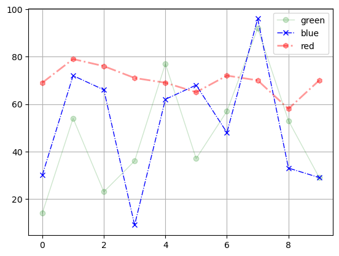

```python
# Eje X común para las tres series superpuestas
x_data = np.arange(10)
# Figura con un solo subplot
fig, axis = plt.subplots(1, 1)
# Primera línea: verde, marcadores círculo, sólida, muy transparente (alpha=0.2)
axis.plot(x_data, np.random.randint(100, size=(10)), 'go-', label='green', linewidth=1, alpha=0.2)
# Segunda línea: azul, marcadores x, guión-punto
axis.plot(x_data, np.random.randint(100, size=(10)), 'bx-.', label='blue', linewidth=1)
# Tercera línea: roja, marcadores hexágono, más gruesa y semitransparente
axis.plot(x_data, np.random.randint(50, 80, size=(10)), 'rh-.', label='red', linewidth=2, alpha=0.4)
# Leyenda que distingue las tres series por color y estilo
axis.legend(loc='best')
# Activa la cuadrícula de fondo para facilitar la lectura de valores
plt.grid()
# Muestra el gráfico con las tres líneas y la rejilla
plt.show()
```

## 2.1 Decoradores

Cambian el aspecto general de la figura

```
axes.set_xticks(<lista>)  # etiquetas del eje
axes.set_title('titulo')  # titulo
axes.set_ylabel('label')
axes.set_frame_on(bool)
```

Más métodos

## 3 Anotaciones

Formas de añadir información sobre el gráfico

```
axes.text(x, y, 'texto')
axes.annotate(texto, xy, xytext, xycoords, arrowprops)
```

Más métodos

```python
# Datos Y aleatorios de longitud 10 para el ejemplo de anotación
y_data = np.random.randint(100, size=(10))  # Cuidado con las dimensiones absolutas
# Eje X con índices 0..9 alineados con y_data
x_data = np.arange(10)
```

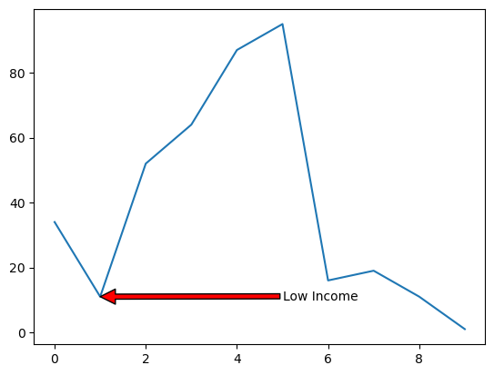

```python
# Figura de un solo eje para añadir una anotación con flecha
fig, axis = plt.subplots(1, 1)
# Gráfico de líneas básico con los datos generados
axis.plot(x_data, y_data)
# axis.text(x_data[1], y_data[1], 'Low income')  # coordenadas igual a los datos
# annotate coloca texto en xytext y una flecha apuntando a xy=(segundo punto)
axis.annotate('Low Income', xy=(x_data[1], y_data[1]), xytext=(5, 10), arrowprops=dict(facecolor='red', shrink=1.0))
# Muestra el gráfico con la anotación destacada
plt.show()
```

## 4 Tipos de gráficos

Ejemplos disponibles como referencia https://matplotlib.org/stable/api/_as_gen/matplotlib.pyplot.subplots.html

```python
# Horizontal bar
# Figura vacía donde dibujaremos barras horizontales
fig, ax = plt.subplots()
# Example data
# Etiquetas de cada barra: nivel de estudios del personal
people = ('PhD', 'MSc', 'BSc', 'N/A')
# Posiciones en el eje Y: 0, 1, 2, 3 para cada categoría
y_pos = np.arange(len(people))
# Porcentaje del personal en cada categoría (debe sumar 100)
percentage = [5, 45, 25, 25]
# Barras horizontales centradas en y_pos con borde rojo y relleno verde
ax.barh(y_pos, percentage, align='center', color='green', edgecolor='red')
# Marca las posiciones numéricas en el eje Y
ax.set_yticks(y_pos)
# Sustituye números por las etiquetas de nivel educativo
ax.set_yticklabels(people)
# ax.invert_yaxis()  # labels read top-to-bottom
# Título del eje X: unidad de la medida mostrada
ax.set_xlabel('Percentage of workforce')
# Título general del gráfico
ax.set_title('Level of education in the company')
# Renderiza el gráfico de barras horizontales
plt.show()
```

[output not shown]

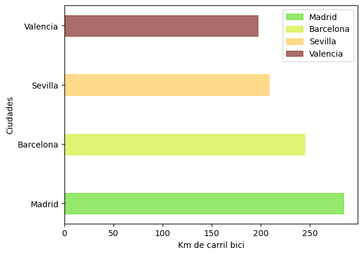

```python
# Kilómetros de carril bici por ciudad (datos absolutos)
ls_count = (284487, 244560, 208493, 196764)
# Nombres de las ciudades correspondientes a cada valor
cities = ('Madrid', 'Barcelona', 'Sevilla', 'Valencia')
# Convierte a miles de km para escalar el eje X y facilitar la lectura
data = np.array(ls_count) / 1000
# Posiciones verticales de cada barra horizontal
y_pos = np.arange(data.size)
# Grosor de cada barra en unidades del eje Y
width = 0.35  # the width of the bars
# Nivel de transparencia del relleno de las barras
opacity = 0.7
# Crea figura y eje para el gráfico de barras
fig, ax = plt.subplots()
# Dibuja barras horizontales; rects1 permite personalizar colores individualmente
rects1 = ax.barh(y_pos, data, width, alpha=opacity)
# Color personalizado para Valencia (última barra, índice 3)
rects1[3].set_color('#872f29')
# Color para Sevilla (índice 2)
rects1[2].set_color('#ffcb59')
# Color para Barcelona (índice 1)
rects1[1].set_color('#d6ee39')
# Color para Madrid (índice 0)
rects1[0].set_color('#6ade30')
# Posiciones de las marcas en el eje Y
ax.set_yticks(y_pos)
# Etiquetas con nombres de ciudad en lugar de índices numéricos
ax.set_yticklabels(cities)
# Etiqueta del eje vertical
ax.set_ylabel('Ciudades')
# Etiqueta del eje horizontal con la unidad (miles de km)
ax.set_xlabel('Km de carril bici')
# Leyenda que asocia cada color con su ciudad
ax.legend((rects1[0], rects1[1], rects1[2], rects1[3]), cities)
# Muestra el gráfico final
plt.show()
```

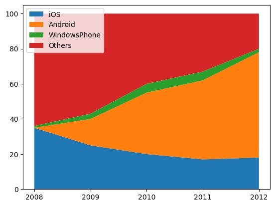

```python
# stack plot
# Años en el eje X del gráfico de áreas apiladas
x = [2008, 2009, 2010, 2011, 2012]
# Cuota de mercado de iOS (%) en cada año
iOS = [35, 25, 20, 17, 18]
# Cuota de Android (%) — crece a lo largo del periodo
Android = [0, 15, 35, 45, 60]
# Cuota de Windows Phone (%)
WindowsPhone = [1, 3, 5, 5, 2]
# Resto de plataformas móviles (%)
Others = [64, 57, 40, 33, 20]
# y = np.vstack([iOS, Android, WindowsPhone, Others])
# print(y)
# Nombres de cada capa para la leyenda
labels = ["iOS ", "Android", "WindowsPhone", "Others"]
# Figura donde apilaremos las áreas de cuota de mercado
fig, ax = plt.subplots()
# stackplot apila las series; la suma en cada x representa el 100% del mercado
ax.stackplot(x, iOS, Android, WindowsPhone, Others, labels=labels)
# ax.stackplot(x, y, labels=labels)
# Fuerza que el eje X muestre exactamente los años indicados
ax.set_xticks(x)
# Leyenda en esquina superior izquierda identificando cada sistema operativo
ax.legend(loc='upper left')
# Renderiza el gráfico de áreas apiladas
plt.show()
```

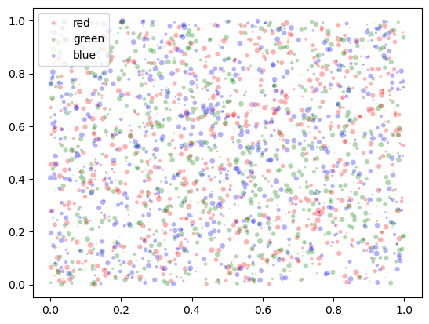

```python
# Scatter plot
# rand genera coordenadas aleatorias uniformes en [0, 1)
from numpy.random import rand

# Figura para el diagrama de dispersión multicolor
fig, ax = plt.subplots()
# Número de puntos a dibujar por cada color
n = 700
# Repite el scatter para rojo, verde y azul con datos independientes
for color in ['red', 'green', 'blue']:
    # Genera n coordenadas x y n coordenadas y aleatorias (matriz 2×n)
    x, y = rand(2, n)
    # Tamaño de cada punto: escala aleatoria entre 0 y 25
    scale = 25.0 * rand(n)
    # Dibuja n puntos del color actual con tamaño variable y transparencia
    ax.scatter(x, y, c=color, s=scale, label=color, alpha=0.3, edgecolors='none')
# Leyenda que identifica cada nube de puntos por color
ax.legend()
# Muestra el scatter plot con las tres series superpuestas
plt.show()
```

### 4.1 Grabar a archivo

`figure.savefig(<filename>, dpi=None, facecolor='w', edgecolor='w', format=None, bbox_inches=None)`

```python
# guardar la figura (puede ser múltiples gráficos)
# os.path.join construye la ruta de salida de forma portable
import os

# Ruta del PNG de salida dentro de la carpeta res
ruta = os.path.join("res", "o_figure.png")
# Guarda la figura activa (fig) en disco con formato PNG
fig.savefig(ruta, format='png')  # varios formatos aceptados ('pdf', 'png', 'svg', 'eps'...)
# Confirma en consola dónde se guardó el archivo
print("Guardado en:", ruta)
```

```
Guardado en: res\o_figure.png
```

# 5 Representación gráfica en pandas

• pandas ofrece interfaz para dibujar Series y DataFrame • Usa matplotlib internamente • Fácil de usar

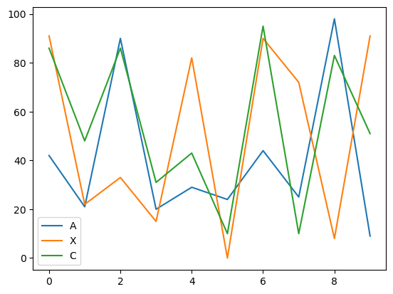

|  | A | X | C |
| --- | --- | --- | --- |
| 0 | 42 | 91 | 86 |
| 1 | 21 | 22 | 48 |
| 2 | 90 | 33 | 86 |
| 3 | 20 | 15 | 31 |
| 4 | 29 | 82 | 43 |
| 5 | 24 | 0 | 10 |
| 6 | 44 | 90 | 95 |
| 7 | 25 | 72 | 10 |
| 8 | 98 | 8 | 83 |
| 9 | 9 | 91 | 51 |

```python
# Matriz aleatoria 10×3 que alimentará el DataFrame
rand_matrix = np.random.randint(100, size=(10, 3))
# DataFrame con columnas A, X y C a partir de la matriz NumPy
frame = pd.DataFrame(rand_matrix, columns=list('AXC'))
# Gráfico de líneas por columna usando la API de Pandas (una serie por columna)
frame.plot()
# Matplotlib aún requiere show() para renderizar en el notebook
plt.show()  # aún es necesario llamar a show() para mostrar los gráficos
# Muestra la tabla de datos que se graficó
display(frame)  # datos en eje x, eje y, leyenda, series?
```

## 6 frame.plot()

`frame.plot(x, y, label=<Series>, ax, style, kind, xticks, yticks, title, subplots)`

• (solo para Series) label: referencia para la leyenda • ax: subfigura en la que dibujar los datos • style: estilo de la línea • kind: tipo de gráfico ('bar', 'pie', 'hist', 'area', 'line', 'barh', 'density', 'kde') • xticks y yticks: valores en los ejes X e Y • title: string como título • (solo para DataFrame) subplots: bool si se desean subfiguras separadas para cada columna • (solo para DataFrame) 'x' e 'y' se pueden utilizar para seleccionar columnas para cada eje

Lista completa de argumentos

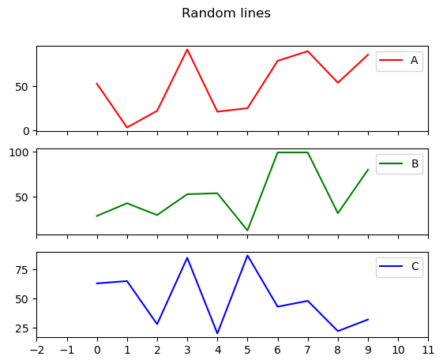

|  | A | B | C |
| --- | --- | --- | --- |
| 0 | 53 | 29 | 63 |
| 1 | 3 | 43 | 65 |
| 2 | 22 | 30 | 28 |
| 3 | 92 | 53 | 85 |
| 4 | 21 | 54 | 20 |
| 5 | 25 | 13 | 87 |
| 6 | 79 | 99 | 43 |
| 7 | 90 | 99 | 48 |
| 8 | 54 | 32 | 22 |
| 9 | 86 | 80 | 32 |

```python
# Nueva matriz aleatoria para el ejemplo con subplots por columna
rand_matrix = np.random.randint(100, size=(10, 3))
# DataFrame con columnas A, B y C
frame = pd.DataFrame(rand_matrix, columns=list('ABC'))
# Tres subplots (uno por columna) con estilos y ticks personalizados
frame.plot(style=['r-', 'g-', 'b-'], xticks=range(-2, 12), title='Random lines', subplots=True)
# Renderiza los tres gráficos generados
plt.show()
# Muestra los datos tabulados junto al gráfico
display(frame)
```

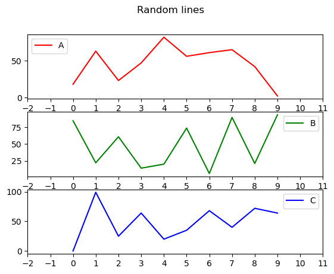

```python
# combinar pandas plot con matplotlib
# Matriz de datos aleatorios para tres series
rand_matrix = np.random.randint(100, size=(10, 3))
# DataFrame fuente de las tres series
frame = pd.DataFrame(rand_matrix, columns=list('ABC'))
# Creamos manualmente 3 subplots verticales para control fino del layout
fig, axis = plt.subplots(3, 1)
# Pasa los ejes creados a pandas para dibujar cada columna en su subplot
ax = frame.plot(style=['r-', 'g-', 'b-'], xticks=range(-2, 12), title='Random lines', subplots=True, ax=axis)
# Coloca la leyenda solo en el primer subplot (índice 0)
ax[0].legend(loc='upper left')
# Muestra la figura combinando control de Matplotlib con plot de Pandas
plt.show()
```

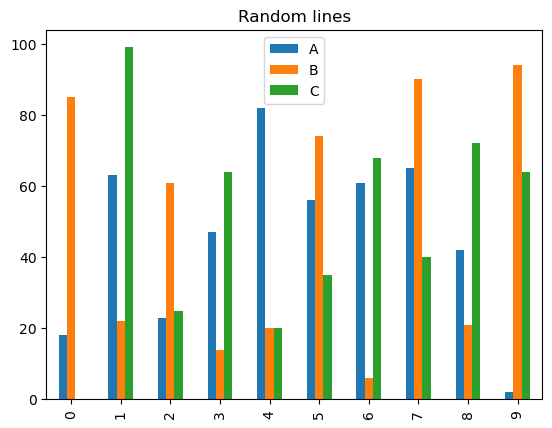

```python
# Gráfico de barras
# Cada columna del DataFrame se representa como grupo de barras
frame.plot(kind='bar', title='Random lines')
# Renderiza el gráfico de barras
plt.show()
```

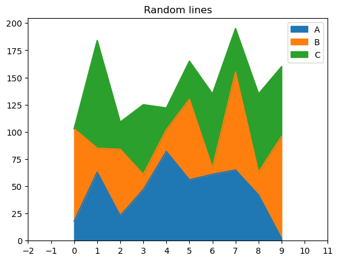

```python
# Gráfico de área
# Áreas apiladas o superpuestas por columna del DataFrame
frame.plot(kind='area', xticks=range(-2, 12), title='Random lines')
# Muestra el gráfico de áreas
plt.show()
```

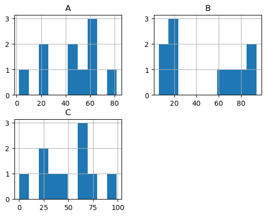

```python
# Histogramas
# Un histograma por columna mostrando la distribución de valores
frame.hist()
# Renderiza todos los histogramas generados
plt.show()
```

|  | mass | radius |
| --- | --- | --- |
| Mercury | 0.33 | 2439.7 |
| Venus | 4.87 | 6051.8 |
| Earth | 5.97 | 6378.1 |

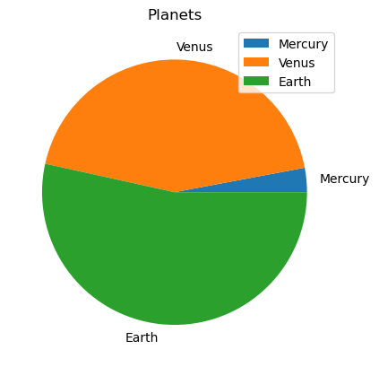

```python
# Gráfico de pastel
# DataFrame con masa y radio de Mercurio, Venus y Tierra
df = pd.DataFrame({'mass': [0.330, 4.87, 5.97],
                   'radius': [2439.7, 6051.8, 6378.1]},
                  index=['Mercury', 'Venus', 'Earth'])
# Muestra la tabla de datos planetarios
display(df)
# Gráfico circular con la columna 'mass' como proporción de cada planeta
df.plot(y='mass', kind='pie', title='Planets')  # y variable a usar
# Renderiza el gráfico de pastel
plt.show()
```

# 7 Seaborn

• Abstracción de matplotlib • Facilidad de uso y personalización • Excelente para exploración y visualización de relaciones entre variables

Viene con varios datasets predefinidos https://github.com/mwaskom/seaborn-data

Documentación oficial

```python
# Importamos Seaborn: capa estadística sobre Matplotlib con estilos y gráficos listos
import seaborn as sns
```

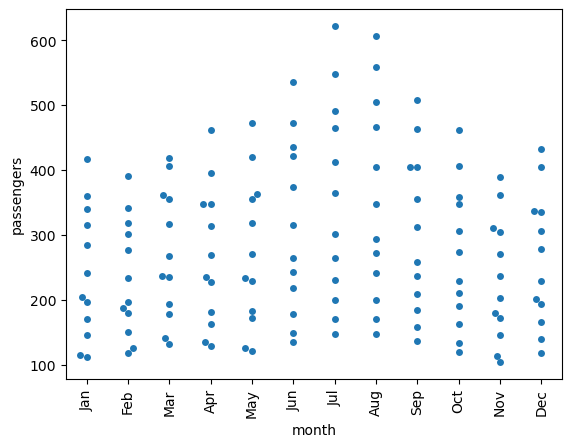

```python
# Load data
# Carga el dataset 'flights' (pasajeros aéreos por mes) incluido en Seaborn
flights_data = sns.load_dataset("flights")
# display(flights_data)
# swarmplot: un punto por observación, separados para ver la densidad por mes
sns.swarmplot(x="month", y="passengers", data=flights_data)
# Rota etiquetas del eje X 90° para que los nombres de mes no se solapen
plt.xticks(rotation=90)
# Muestra el swarmplot final
plt.show()
```

Compatible con pandas

```python
# Load in data
# Lee el CSV de propinas en restaurante desde el repositorio de seaborn-data
tips = pd.read_csv("https://raw.githubusercontent.com/mwaskom/seaborn-data/master/tips.csv")
# Muestra 5 filas aleatorias para inspeccionar columnas y valores
tips.sample(5)
```

|  | total_bill | tip | sex | smoker | day | time | size |
| --- | --- | --- | --- | --- | --- | --- | --- |
| 152 | 17.26 | 2.74 | Male | No | Sun | Dinner | 3 |
| 131 | 20.27 | 2.83 | Female | No | Thur | Lunch | 2 |
| 93 | 16.32 | 4.30 | Female | Yes | Fri | Dinner | 2 |
| 58 | 11.24 | 1.76 | Male | Yes | Sat | Dinner | 2 |
| 36 | 16.31 | 2.00 | Male | No | Sat | Dinner | 3 |

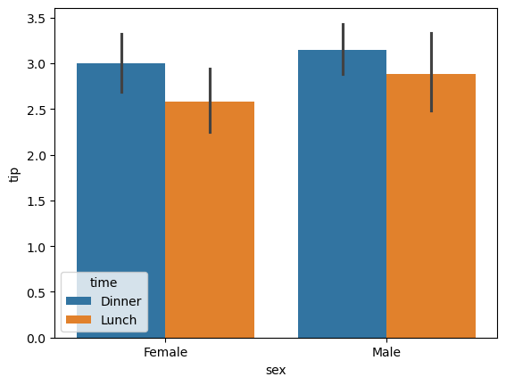

```python
# Barras con la propina media (y) agrupada por sexo y franja horaria (hue)
sns.barplot(x='sex', y='tip', hue='time', data=tips)  # palette para color (negro desviacion)
# Renderiza el gráfico de barras con intervalos de confianza
plt.show()
```

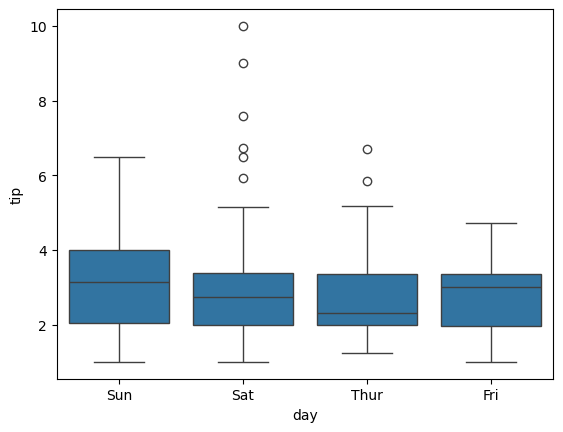

```python
# Boxplot (cuartiles)
# Diagrama de caja de propinas por día de la semana
sns.boxplot(x='day', y='tip', data=tips)
# sns.boxplot(x=tips['day'], y=tips.tip)
plt.show()
```

## 7.1 Relaciones entre variables

`sns.relplot()`

```python
# Vuelve a cargar 'tips' desde los datasets integrados de Seaborn
tips = sns.load_dataset("tips")
# Muestra una muestra aleatoria de 5 registros
tips.sample(5)
```

|  | total_bill | tip | sex | smoker | day | time | size |
| --- | --- | --- | --- | --- | --- | --- | --- |
| 161 | 12.66 | 2.5 | Male | No | Sun | Dinner | 2 |
| 73 | 25.28 | 5.0 | Female | Yes | Sat | Dinner | 2 |
| 122 | 14.26 | 2.5 | Male | No | Thur | Lunch | 2 |
| 52 | 34.81 | 5.2 | Female | No | Sun | Dinner | 4 |
| 86 | 13.03 | 2.0 | Male | No | Thur | Lunch | 2 |

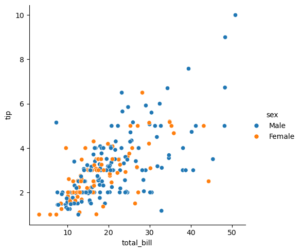

```python
# Scatter de total_bill vs tip, coloreado por sexo
sns.relplot(x='total_bill', y='tip', hue='sex', data=tips, kind='scatter')
# Muestra la relación bivariante entre cuenta y propina
plt.show()
```

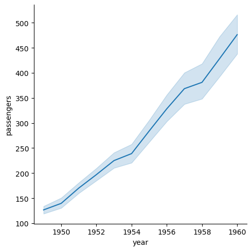

```python
# representar la media y la variación de una variable en función de otra
# Dataset de pasajeros aéreos anuales
data = sns.load_dataset('flights')
# Gráfico de líneas: evolución de pasajeros por año con banda de incertidumbre
sns.relplot(x="year", y="passengers", kind="line", data=data)
# Renderiza la serie temporal
plt.show()
```

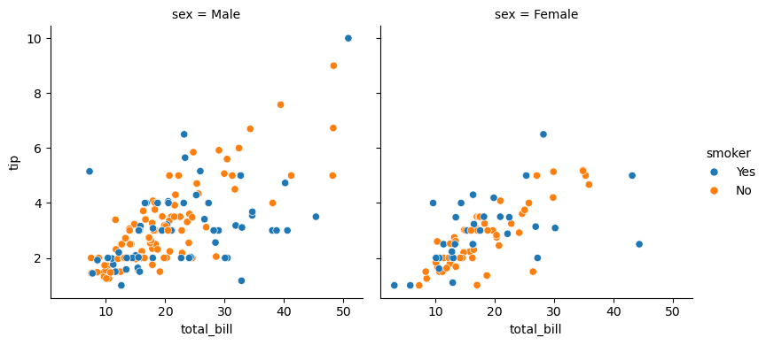

```python
# relacionar hasta 4 variables automáticamente
# Scatter de cuenta vs propina, color por fumador, facetas separadas por sexo
sns.relplot(x="total_bill", y="tip", hue="smoker",
            col="sex", height=4,
            kind="scatter", data=tips)  # kind ('line','scatter'...)
# Muestra una cuadrícula de gráficos (una columna por valor de sex)
plt.show()
```